# Imports and functions definitions

```python
import pandas as pd
import os.path as path
import numpy as np
import pandas as pd
import pandas as pd
import os.path as path
import numpy as np
from datetime import datetime, timezone
import matplotlib.pyplot as plt

def calc_market_share(input_data, condition='ilevel_0 in ilevel_0'):
    market_share = {}
    data = input_data.query(condition)
    idx = {col: data.columns.get_loc(col) for col in data.columns}
    #print(data.head(50).to_string())

    for row in data.values:
        supplier = row[idx['SupplierName']]
        market_share.setdefault(supplier, [0, 0])
        market_share[supplier][0] += row[idx['ValueMax']]
        market_share[supplier][1] += row[idx['NumberOfEmployees']]

    #print(market_share.values())
    sum_value = sum(x[0] for x in list(market_share.values()))
    price_per_employee = {k: v[0] / v[1] for k, v in market_share.items()}
    market_share = {k: v[0] / sum_value for k, v in market_share.items()}

    # print("Condition: {}".format(data['Region'].unique()))
    # print("Shares: {}".format(market_share))
    return market_share, price_per_employee

def load_data():
    data_dir = "."
    publishers = pd.read_csv(path.join(data_dir, "publishers.csv"), sep=';')
    contracts = pd.read_csv(path.join(data_dir, "contracts.csv"), sep=';')
    return publishers, contracts


def create_query_string(relevantICs):
    query = ""
    for ic in relevantICs:
        if len(query) > 0:
            query += " or "
        query += "SupplierIC == {}".format(ic)
    return query


def preprocess_data(publishers, contracts, relevantICs):
    query_string = create_query_string(relevantICs)

    # filter irrelevant contracts
    flt = contracts.query(query_string).reset_index()

    # filter-out contracts without monetary information
    flt = flt.dropna(subset=['ValueVatExcluded', 'ValueVatIncluded'], how='all')

    # convert Value columns to numeric and convert NaNs to 0
    flt[["ValueVatIncluded", "ValueVatExcluded"]] = flt[["ValueVatIncluded", "ValueVatExcluded"]].apply(
        pd.to_numeric).fillna(0)

    # Values with VAT and without VAT aren't very consistent, take max of both columns
    value_max_col = flt[['ValueVatExcluded', 'ValueVatIncluded']].max(axis=1)

    # convert to UTC datetime
    flt['Date'] = pd.to_datetime(flt['PublishedAtUtc'], utc=True)

    # drop unnecessary columns
    flt = flt.drop(['index', 'ValueVatExcluded', 'ValueVatIncluded', 'PublishedAtUtc'], axis=1)

    # insert value max column instead of two Value columns
    flt.insert(4, 'ValueMax', value_max_col)

    # merge with publishers
    merged = flt.merge(publishers, on='PublisherIC', how='inner')
    return merged


def which_quartal(date):
    return "Q{} {}".format(int(date.month / 3 + 1), date.strftime('%y'))
```

# Preparation of data

```python
# main function
publishers, contracts = load_data()

# ICs of companies in the food voucher business
relevantICs = np.array([61860476, 62913671, 24745391], dtype=np.int)

clean_data = preprocess_data(publishers, contracts, relevantICs)
calc_market_share(clean_data)

first_contract = pd.to_datetime(clean_data.sort_values('Date', ascending=True).head(1).Date.values[0], utc=True)
last_contract = pd.to_datetime(clean_data.sort_values('Date', ascending=False).head(1).Date.values[0], utc=True)
start = datetime(first_contract.year, int(first_contract.month / 3) * 3 + 1, day=1, tzinfo=timezone.utc)
one_quartal = pd.DateOffset(months=3)
end = datetime(last_contract.year, last_contract.month, day=1, tzinfo=timezone.utc) + pd.DateOffset(months=1)
```

# Market Shares in Years

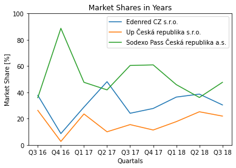

```python
share_per_quartal = {}
employee_price = {}

while start < end:
    next_quartal = start + one_quartal
    #print("time period: from {}, to {}, pretty: {}".format(start, next_quartal, start.strftime('%B %Y')))
    share_per_quartal[which_quartal(start)], employee_price[which_quartal(start)] = calc_market_share(clean_data, "Date > @start and Date < @next_quartal")
    start += one_quartal

suppliers = clean_data.SupplierName.unique()
plt.title('Market Shares in Years')
for supplier in suppliers:
    plt.plot(list(share_per_quartal.keys()), [100 * x[supplier] for x in list(share_per_quartal.values())])
plt.xlabel('Quartals')
plt.ylabel('Market Share [%]')
plt.gca().legend(suppliers)
plt.gca().set_ylim([0, 100])
plt.show()
```

# Market Shares in Regions

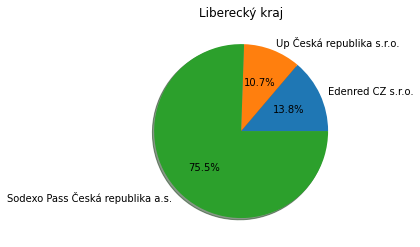

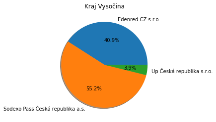

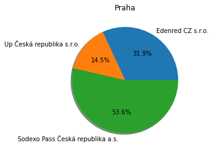

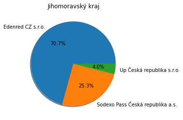

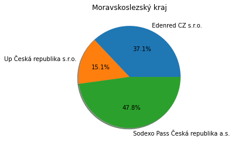

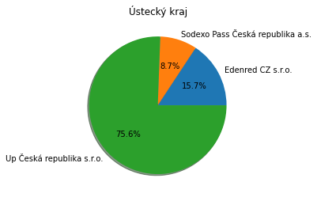

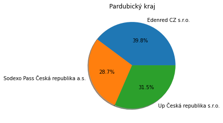

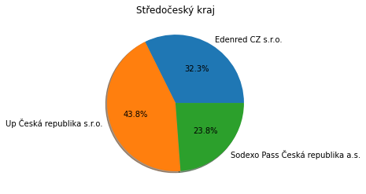

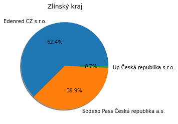

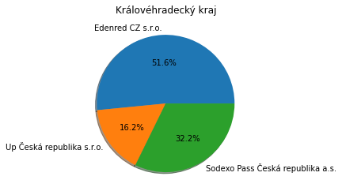

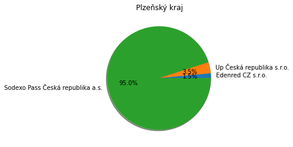

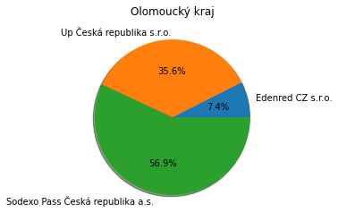

[2 more figures not shown]

```python
data_by_region = {}
price_per_region = {}

distinct_regions = clean_data['Region'].unique()
for item in distinct_regions:
    data_by_region[item], price_per_region[item] = calc_market_share(clean_data, "Region == @item")
#print(data_by_region)

for item in distinct_regions:
    plt.title('{}'.format(item))
    plt.pie(x=data_by_region[item].values(), labels=list(data_by_region[item].keys()), autopct='%1.1f%%',
        shadow=True)
    plt.show()

#print(clean_data.head(10).to_string())
```

# Price per Employee in Years

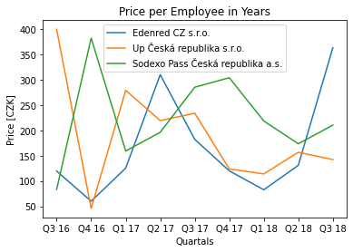

```python
plt.title('Price per Employee in Years')
for supplier in suppliers:
    plt.plot(list(employee_price.keys()), [x[supplier] for x in list(employee_price.values())])
plt.xlabel('Quartals')
plt.ylabel('Price [CZK]')
plt.gca().legend(suppliers)
#plt.gca().set_ylim([0, 100])
plt.show()
```

# Questions

A. Can you make a food voucher market share model for the country or selected regions? How do you best compute a market share using all the information that you have in the dataset?

Food voucher market share model for selected regions can be found in section "Market Shares in Regions" of this notebook. Market share is computed as maximum of columns Values with VAT and without VAT. Before that, contracts without monetary information are filtred-out and NaNs are converted to 0. Another way can be to sum number of unique companies and their employees.

B. Is any of the suppliers gaining more market share or experiencing revenue growth in the public sector during the observed period? If so, which supplier over whom and how sure are you of this trend?

Market share of the suppliers can be found in section "Market Shares in Years" of this notebook. Due to the fact that for months it was too many data, market shares are computed for quartals of years. From the graph can be seen, that Sodexo Pass CR a.s. is dominating. Market share is bigger for Edenred CZ s.r.o. only in 3 out of 9 quartals (1/3). These quartals are Q3 16, Q2 17 and Q2 18. It is also clear from the graph, that market shares are smallest for Up CR s.r.o. Although the data are fluctuating, it is pretty obvious, that biggest share has Sodexo Pass CR a.s. followed by Edenred CZ s.r.o. and by Up CR s.r.o.

C. Is any of the buyers/publishers consistently negotiating unusually high or low prices? Are there any reasons you can think of why this is possible?

Average prices per one employee in quartals are shown in section "Price per Employee in Years". Unusually high or low prices are caused by lack of data.